# LAB4

```python
%matplotlib inline
import numpy as np
import matplotlib
import matplotlib.pyplot as plt
import scipy
from scipy import stats
import h5py

#this sets the size of the plot to something useful
plt.rcParams["figure.figsize"] = (20,15)
```

```python
hf = h5py.File('gammaray_lab4.h5', 'r')
```

```python
hf.keys()
```

```
<KeysViewHDF5 ['data']>
```

```python
hf
```

```
<HDF5 file "gammaray_lab4.h5" (mode r)>
```

# Problem 1

```python
with h5py.File('gammaray_lab4.h5', 'r') as hf:
    data = np.array(hf.get('data'))
```

1.Plot some data to see what's going on first

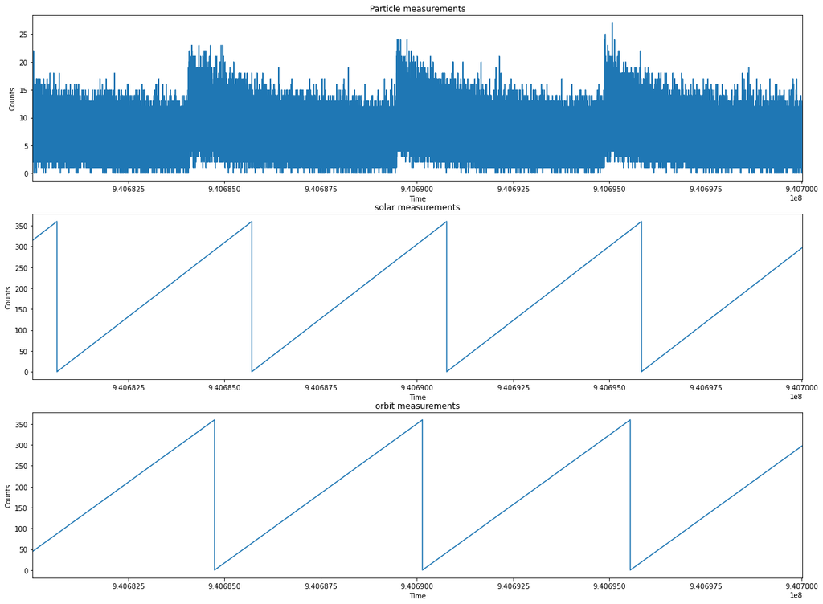

```python
N=200000
plt.subplot(3,1,1)
plt.plot(data[0][0:N], data[3][0:N]);
plt.xlim(data[0][0], data[0][N])
plt.title("Particle measurements")
plt.xlabel('Time')
plt.ylabel('Counts')

plt.subplot(3,1,2)
plt.plot(data[0][0:N], data[1][0:N]);
plt.xlim(data[0][0], data[0][N])
plt.title("solar measurements")
plt.xlabel('Time')
plt.ylabel('Counts')

plt.subplot(3,1,3)
plt.plot(data[0][0:N], data[2][0:N]);
plt.xlim(data[0][0], data[0][N])
plt.title("orbit measurements")
plt.xlabel('Time')
plt.ylabel('Counts')
```

2) The background is not consistent across the dataset. Find and describe as accurately as you can how the background changes.

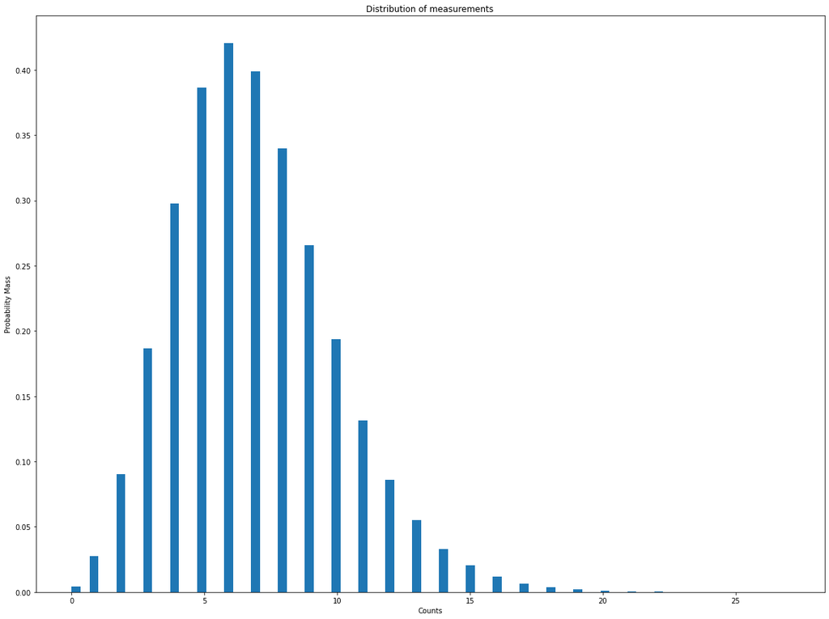

```python
plt.title('Distribution of measurements')
plt.xlabel('Counts')
plt.ylabel('Probability Mass')
plt.hist(data[3][0:N], bins=80, density=True);
```

We can see for the distribution the graph looks like a possion distribution and the mean is about 7

3) Create a model for the background that includes time dependence, and explicitly compare your model to the data. How good is your model of the background?

Draw a possion distribution and the mean is about 7 and compare it with the graph above

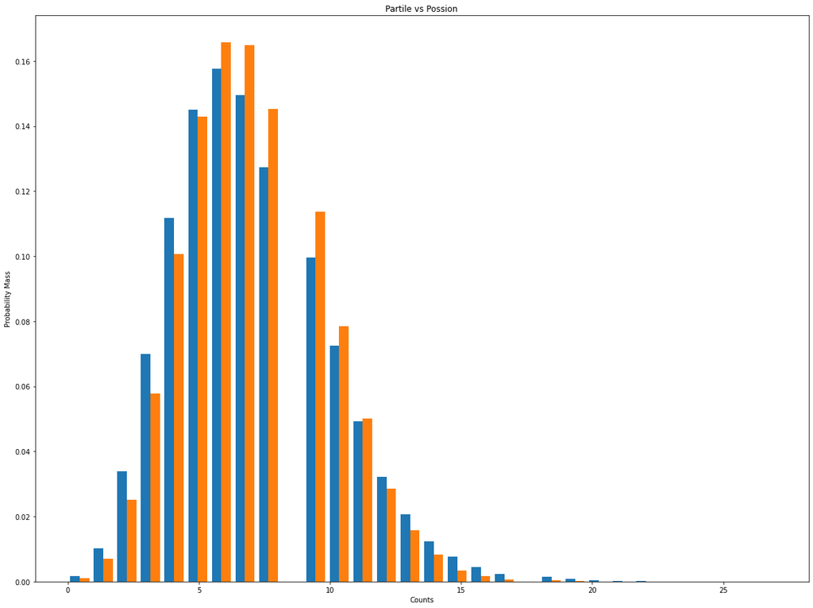

```python
dist = stats.poisson(7)
vals = dist.rvs(N)
plt.hist([data[3][0:N], vals], bins=30, density=True)
plt.title('Partile vs Possion')
plt.xlabel('Counts')
plt.ylabel('Probability Mass')
```

As we can see the raw data is not follwing the possion distribution very well,poisson distribution slightly overpresidct but because it is raw data it is ok to have that, over all the graph shows a good tread.

4) Because the background varies, your discovery sensitivity threshold (how many particles you would need to see) also varies. What is the '5-sigma' threshold for a 100 millisecond GRB at different times?

```python
sig=stats.norm.sf(5)
five_counts=int(stats.poisson.isf(sig,5))
six_counts = int(stats.poisson.isf(sig,7))
print('For 5 counts, a 5 sigma threshold value is ' + str(five_counts))
print('For 6 counts, a 5 sigma threshold value is ' + str(six_counts))
```

```
For 5 counts, a 5 sigma threshold value is 20
For 6 counts, a 5 sigma threshold value is 24
```

# Problem 2

I will be working on transient.

1) Dowload the data from images.h5. This is a stack of 10 square images, each 200 pixels on a side.

```python
hf = h5py.File('images.h5', 'r')
hf.keys()
data = np.array(hf.get('imagestack'))
hf.close()
```

2) Explore the data. Is there signal contamination? Is the background time dependent? Is it consistent spatially? Develop a plan to calculate your background pdf().

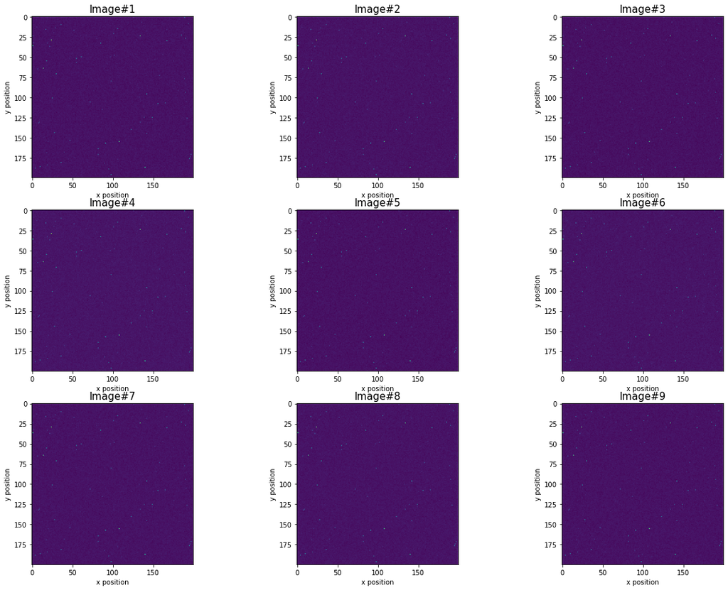

```python
fig,ax = plt.subplots(3, 3)

ax[0,0].imshow(data[:,:,0])
ax[0,0].set_title("Image#1",fontsize=15)
ax[0,0].set_xlabel("x position",fontsize=10)
ax[0,0].set_ylabel("y position",fontsize=10)

ax[0,1].imshow(data[:,:,1])
ax[0,1].set_title("Image#2",fontsize=15)
ax[0,1].set_xlabel("x position",fontsize=10)
ax[0,1].set_ylabel("y position",fontsize=10)

ax[0,2].imshow(data[:,:,2])
ax[0,2].set_title("Image#3",fontsize=15)
ax[0,2].set_xlabel("x position",fontsize=10)
ax[0,2].set_ylabel("y position",fontsize=10)

ax[1,0].imshow(data[:,:,3])
ax[1,0].set_title("Image#4",fontsize=15)
ax[1,0].set_xlabel("x position",fontsize=10)
ax[1,0].set_ylabel("y position",fontsize=10)

ax[1,1].imshow(data[:,:,4])
ax[1,1].set_title("Image#5",fontsize=15)
ax[1,1].set_xlabel("x position",fontsize=10)
ax[1,1].set_ylabel("y position",fontsize=10)

ax[1,2].imshow(data[:,:,5])
ax[1,2].set_title("Image#6",fontsize=15)
ax[1,2].set_xlabel("x position",fontsize=10)
ax[1,2].set_ylabel("y position",fontsize=10)

ax[2,0].imshow(data[:,:,6])
ax[2,0].set_title("Image#7",fontsize=15)
ax[2,0].set_xlabel("x position",fontsize=10)
ax[2,0].set_ylabel("y position",fontsize=10)

ax[2,1].imshow(data[:,:,7])
ax[2,1].set_title("Image#8",fontsize=15)
ax[2,1].set_xlabel("x position",fontsize=10)
ax[2,1].set_ylabel("y position",fontsize=10)

ax[2,2].imshow(data[:,:,8])
ax[2,2].set_title("Image#9",fontsize=15)
ax[2,2].set_xlabel("x position",fontsize=10)
ax[2,2].set_ylabel("y position",fontsize=10)
```

For those 9 graphs there are consistent spatially, and we can't see supernova in our eyes.

We can then determin the background pdf by draw a graph of average brightness distribution of the star

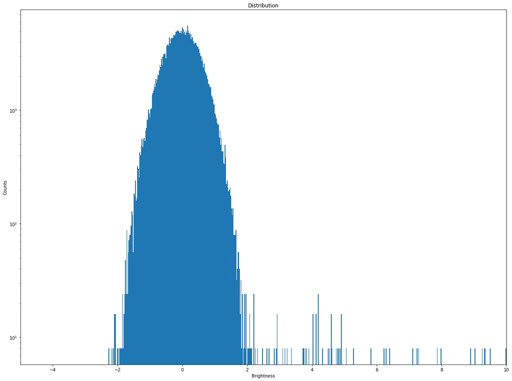

```python
average = []
ave=[]
for i in range(200):
    for j in range(200):
        for k in range(8):
            ave = np.mean(data[i,j,0])
            average.append(ave)

plt.hist(average, bins = 'auto');
plt.xlim(-5,10);
plt.yscale('log')
plt.title('Distribution')
plt.xlabel('Brightness')
plt.ylabel('Counts')
```

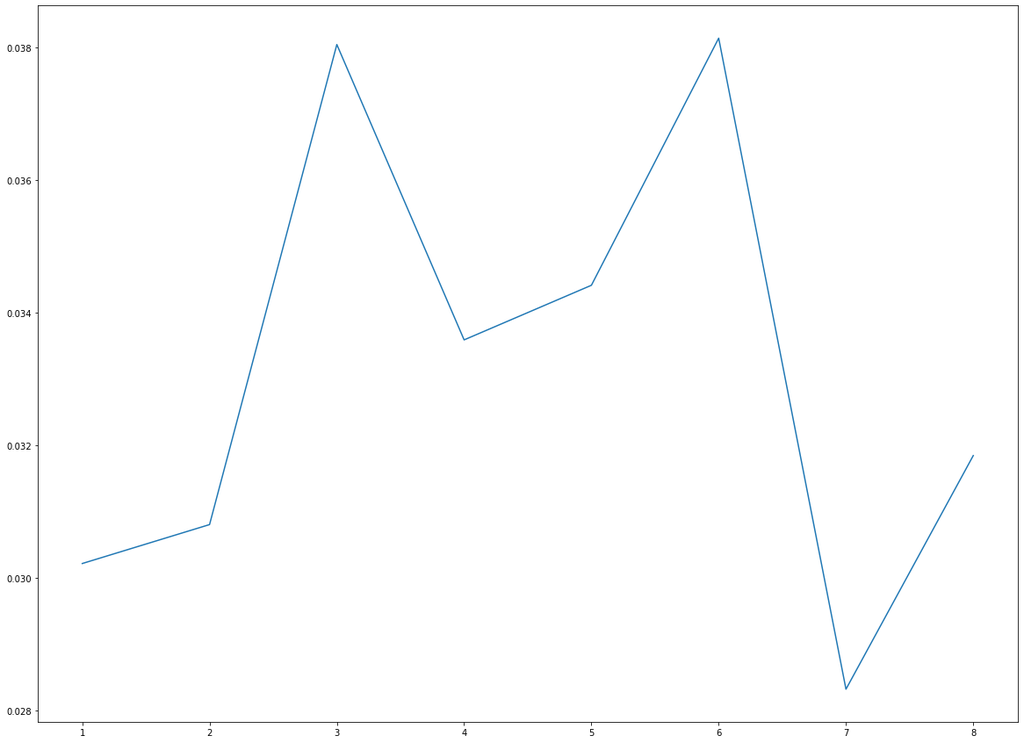

```python
means=[]
for k in range(8):
    ave = np.mean(data[:,:,k])
    means.append(ave)
plt.plot(np.arange(1,9,1),means)
```

We can see the mean is change with different graph the background is time dependent

3) Using your background distribution, hunt for your signal (transient). Describe what you find.

```python
maxs = np.zeros(9)
for u in range(0,9):
    maxs[u] = (data[0:200,0:200,u]).max()
print(maxs)
```

```
[46.01175269 46.59226706 47.7901082  46.0811206  47.00038657 46.62131603
 46.99131843 47.2632494  46.48839435]
```

The highest brighness of all 9 image are apprea to be around 46 so that is the supernova we are looking for, out of them all, image 3 was highest so that is what we are looking for in those 9 images. Because the background is time dependent the brightness would change, so all the nine max are the same star located at same location.

Find the location of the star in image 3 which is located at around 5 sigma

```python
x=0
y=0
for i in range(200):
    for j in range(200):
        if data[i,j,2] > 45:
            x=i
            y=j
print('the brightest start is located at'+str(x)+','+str(y))
```

```
the brightest start is located at36,1
```

I am not sure of my understanding of transient, if the transient is the higest brightness of the image then it was located at(36,1), if it only appears on 1 image and will vanish after 1 image then it would not exist in the first 9 image

4

The final pdfs were different because we were both looking at differnt bounds of the background. For faintest stars we will use the image as background to find 5 sigma and for super nova we need to find the time vs brightness. The averages we used in our distributions were based around different local values.